# General Philosophy

Week 1: Scepticism

Jonny McIntosh

# COURSE OVERVIEW

1. Knowledge and Scepticism 1
2. Knowledge and Scepticism 2
3. Induction
4. Descartes: God, Mind and Body
5. Mind and Body Continued
6. Personal Identity
7. Free Will
8. Problems of Evil

# WHAT IS SCEPTICISM?

**SCEPTICS** claim that, for any proposition P of a certain specified set, you do not know P.

Sceptics often argue that you do not know P because you *cannot* know P.

**GLOBAL** scepticism targets *all* propositions.

**LOCAL** scepticism targets propositions in specific domains:

- other minds,
- the past,
- unobserved objects and events,
- the external world.

This week, two kinds of argument for scepticism concerning beliefs about the external world:

- **SCEPTICAL SCENARIO** arguments;
- Hume's argument, concerning the objects of perception.

# SCEPTICAL SCENARIOS

[figure not shown]

**ACTORS**

Everyone around you is an actor, pretending to be a philosophy student. It seems to you that you are surrounded by philosophy students, but in fact you're not.

[figure not shown]

**ROBOT**

Everyone around you is a cunningly designed robot, that looks and behaves just like a human. It seems to you that you are surrounded by humans, but in fact you're not.

[figure not shown]

**DREAMING**

You are fast asleep, dreaming that you are in a philosophy lecture, listening to me talk about scepticism. It seems to you that I am talking right now, but in fact I'm not.

[figure not shown]

**EVIL DEMON**

You are being deceived by an evil demon into believing that you are an ordinary person. It seems to you that you have hands, but in fact you don't.

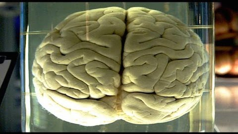

**BRAIN IN A VAT**

You are a brain in a vat (BIV), manipulated by a deranged scientist into believing that you are an ordinary person. It seems to you that you have hands, but in fact you don't.

A sceptical scenario is (purports to be) **SUBJECTIVELY INDISTINGUISHABLE** from how things are: how things seem to you in the scenario is the same as how things in fact seem to you.

(The claim is *not* that you have the same experiences or evidence as you in fact have. That will depend on one's theory of experiences and evidence.)

Sceptical scenarios *purport* to be subjectively indistinguishable from how things in fact are. But in some cases, one might wonder whether this is so.

For example, while we often can't tell that we are dreaming when we are, one might think we *can* tell that we are not when we are not.

If a sceptical scenario *is* subjectively indistinguishable from how things in fact are, it seems to follow that you cannot know that it does not obtain.

How so?

1. If a sceptical scenario is subjectively indistinguishable from how things are, you cannot rule out the possibility that the scenario obtains.
2. If one cannot rule out the possibility that a scenario obtains, you cannot know that it does not obtain.
3. So, if a sceptical scenario is subjectively indistinguishable from how things are, you cannot know that it does not obtain.

Let's grant this, and that **BRAIN IN A VAT** is genuinely subjectively indistinguishable from how things are. It follows that you do not know that you are not a brain in a vat.

That's worrying enough, but the sceptic doesn't want to stop here.

In sceptical scenarios, certain **TARGET PROPOSITIONS** - certain propositions that we ordinarily take ourselves to know - are false.

In **BRAINS IN VATS**, for example, even the proposition that you have hands is false - you are really just a (handless) plaything in the laboratory of a deranged scientist.

The sceptic's ultimate ambition is to show that you cannot know these targeted propositions.

How does the argument go?

1. You know that the proposition that you have hands entails the proposition that you are not a BIV.
2. If you know that the proposition that you have hands entails the proposition that you are not a BIV, and you can know that you have hands, then you can know that you are not a BIV.
3. So, if you can know that you have hands, you can know that you are not a BIV.

Equivalently: if you cannot know that you are not a BIV, you cannot know that you have hands.

But (we've granted) you cannot know that you are not a BIV.

So you cannot know that you have hands!

At least at first sight, the argument for the claim that if you cannot know that you are not a BIV, you cannot know that you have hands is very hard to resist:

1. You know that the proposition that you have hands entails the proposition that you are not a BIV.
2. If you know that the proposition that you have hands entails the proposition that you are not a BIV, and you can know that you have hands, then you can know that you are not a BIV.
3. So, if you can know that you have hands, you can know that you are not a BIV.

Premise 1. attributes a very trivial piece of knowledge to you - knowledge that the proposition that you have hands entails the proposition that you are not a BIV.

Premise 2. is an instance of a plausible principle, **EPISTEMIC CLOSURE**:

If one knows that P entails Q, and one can know that P, then one can know that Q.

**EPISTEMIC CLOSURE** is not to be confused with the very *im*plausible, principle:

If P entails Q, and one can know that P, then one can know that Q.

**EPISTEMIC CLOSURE** is the principle that knowledge is closed under *known* entailment, not that it is closed under *entailment*.

Despite its plausibility, some philosophers argue against **EPISTEMIC CLOSURE**.

We'll come back to this next week.

Summarising:

1. You cannot know that you are not a brain in a vat.
2. If you cannot know that you are not a brain in a vat, you cannot know that you have hands.
3. So, you cannot know that you have hands.

# HUME'S ARGUMENT

The line of argument we have been exploring is associated with Descartes.

But Descartes himself is not ultimately a sceptic about the external world.

Descartes thinks we have a strong natural inclination to believe in external objects.

And he thinks we have a guarantee that this inclination is correct. If it weren't, Descartes thinks, God would be a deceiver. But God, he argues, is not a deceiver.

Hume agrees that we have a strong natural inclination to believe in external objects:

"It seems evident that men are carried by a natural instinct or pre-possession to repose faith in their senses; and that, without any reasoning, or even almost before the use of reason, we always suppose an external universe which depends not on our perception, but would exist though we and every sensible creature were absent or annihilated."

Hume, *Enquiry concerning Human Understanding*, §12, P7.

But this is because our natural inclination leads us to **FALSELY** suppose that our perceptions are themselves mind-independent, external objects:

"The table which we see seems to diminish as we remove farther from it: But the real table, which exists independently of us, suffers no alteration: It was therefore nothing but its image which was present to the mind."

Hume, *Enquiry concerning Human Understanding*, §12, P9.

Hume's reasoning:

1. The table that is present to the mind gets smaller as we move away.
2. The external table does not get smaller as we move away.
3. So, the table that is present to the mind is not the external table.

Alternatively, consider the famous Müller-Lyre Illusion:

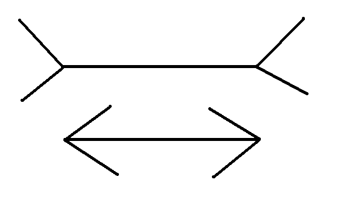

**Müller-Lyre Illusion**

An argument from illusion:

1. The lines that are present to the mind are of differing lengths.
2. The external lines are not of differing lengths.
3. So, the lines that are present to the mind are not the external lines.
4. The sort of thing that's present to the mind in this illusion is the same as the sort of thing that's present to the mind in veridical perception.
5. So the sort of thing that's present to the mind in veridical perception is not an external object.

Hume thinks that, in response to this finding, philosophers (Locke) adopt a more sophisticated view, according to which our perceptions are **CAUSED** by mind-independent, external objects.

Hume doesn't argue this view is false. But he thinks there can be no proof that it is correct.

"It is a question of fact whether the perceptions of the senses be produced by external objects resembling them: how shall this question be determined? By experience surely; as all other questions of a like nature. But here experience is and must be entirely silent. The mind has never anything present to it but the perceptions, and cannot possibly reach any experience of their connexion with objects. The supposition of such a connexion is, therefore, without foundation in reasoning."

Hume, *Enquiry concerning Human Understanding*, §12, P12.

Nor can we follow Descartes and appeal to God:

"If [God's] veracity were at all concerned in this matter, our senses would be entirely infallible; because it is not possible that he can ever deceive. Not to mention that if the external world be once called in question, we shall be at a loss to find arguments by which we may prove the existence of that Being or any of his attributes."

Hume, *Enquiry concerning Human Understanding*, §12, P13.

Summarising:

Belief in an external world is either based on the belief that perceptions *are* external objects or the belief that perceptions are *caused* by external objects.

1. The first belief is natural but false.
2. The second might be true, but we can find no convincing argument for it.

So our belief in an external world has no basis in reason.

What we make of this argument depends, among other things, on what we make of Hume's case for thinking that what is present to the mind are not external, mind-independent objects, but images.

Hume himself thinks the argument itself is unassailable:

"This is a topic, therefore, in which the profounder and more philosophical sceptics will always triumph when they endeavour to introduce an universal doubt into all subjects of human knowledge and enquiry."

Hume, *Enquiry concerning Human Understanding*, §12, P14.

But note that to say that our belief has no basis in reason is not necessarily the same as to say that it is unreasonable.

And Hume's attitude to such scepticism is complex:

"here is the chief and most confounding objection to excessive scepticism, that no durable good can ever result from it; while it remains in its full force and vigour. We need only ask such a sceptic, *What his meaning is? And what he proposes by all these curious researches?*"

Hume, *Enquiry concerning Human Understanding*, §12, P23.

Does the sceptic really expect us to stop believing in an external world?

First, while our belief in the external world is unsupported by reason, giving it up is psychologically impossible:

"though a Pyrrhonian may throw himself or others into a momentary amazement and confusion by his profound reasonings; the first and most trivial event in life will put to flight all his doubts and scruples, and leave him the same, in every point of action and speculation, with the philosophers of every other sect, or with those who never concerned themselves in any philosophical researches."

Hume, *Enquiry concerning Human Understanding*, §12, P23.

Second, and even if we could give it up, we wouldn't want to:

"all human life must perish were [the sceptic's] principles universally and steadily to prevail. All discourse, all action would immediately cease; and men remain in a total lethargy, till the necessities of nature, unsatisfied, put an end to their miserable existence."

Hume, *Enquiry concerning Human Understanding*, §12, P23.

# SUMMARY

We've looked at:

- **SCEPTICAL SCENARIO** arguments;
- Hume's argument, concerning the senses.

Sceptical scenario arguments:

1. You cannot know that **SCEPTICAL SCENARIO** doesn't obtain.
2. If you cannot know that **SCEPTICAL SCENARIO** doesn't obtain, you cannot know **TARGETED PROPOSITION**.
3. So, you cannot know **TARGETED PROPOSITION**.

Hume's argument:

Belief in an external world is either based on the belief that perceptions *are* external objects or the belief that perceptions are *caused* by external objects.

1. The first belief is natural but false.
2. The second might be true, but we can find no convincing argument for it.

So our belief in an external world has no basis in reason.

Hume's attitude to such scepticism is markedly ambivalent. He thinks the argument is in some sense irresistable, but nevertheless practically ineffective.

We can't give up belief in the external world and, even if we could, we wouldn't want to.

Next week: how thinking about knowledge might help us resist arguments based on sceptical scenarios.